# Practical Machine Learning : Prediction

Utkarsh Chauhan

9/4/2020

## Introduction

Using devices such as Jawbone Up, Nike FuelBand, and Fitbit it is now possible to collect a large amount of data about personal activity relatively inexpensively. These type of devices are part of the quantified self movement – a group of enthusiasts who take measurements about themselves regularly to improve their health, to find patterns in their behavior, or because they are tech geeks. One thing that people regularly do is quantify how much of a particular activity they do, but they rarely quantify how well they do it. In this project, your goal will be to use data from accelerometers on the belt, forearm, arm, and dumbell of 6 participants. They were asked to perform barbell lifts correctly and incorrectly in 5 different ways. More information is available from the website here: http://groupware.les.inf.puc-rio.br/har .

## Package Required and Data Loading

The training data for this project are available here:

https://d396qusza40orc.cloudfront.net/predmachlearn/pml-training.csv

The test data are available here:

https://d396qusza40orc.cloudfront.net/predmachlearn/pml-testing.csv

```r
library(caret)
library(randomForest)

# Set seed for reproducibility
set.seed(3339)

## Data for training and cross-validation
if ( !file.exists("pml-training.csv") ) {
    download.file('https://d396qusza40orc.cloudfront.net/predmachlearn/pml-training.csv',
                  'pml-training.csv')
}

## Data for testing
if ( !file.exists("pml-testing.csv") ) {
    download.file('https://d396qusza40orc.cloudfront.net/predmachlearn/pml-testing.csv',
                  'pml-testing.csv')
}

## Loading data
data <- read.csv('pml-training.csv')
test <- read.csv('pml-testing.csv')
```

## Data Processing

- Remove variables which are having NA values (threshold 95%).
- Remove variables which are having nearly zero variance
- Remove variables which are not required such as *user_name*, *raw_timestamp_part_1*, *raw_timestamp_part_2*, *cvtd_timestamp*, and *num_window* (columns 1 to 6).

```r
## Removing columns with more than 95% missing values
missing <- which(apply(data, 2, function(col) mean(is.na(col)))>.95)
data <- subset(data,select = -missing)
test <- subset(test,select = -missing)

## Removing columns having near zero variance
near_zero <- nearZeroVar(data)
data <- subset(data,select = -near_zero)
test <- subset(test,select = -near_zero)

## Removing first 6 columns
data <- subset(data,select = -c(1:6))
test <- subset(test,select = -c(1:6))

## Convert classes into factor variable
data$classe <- as.factor(data$classe)
```

- partition the training data into training set and cross validation set using *classe* variable.

```r
inTrain <- createDataPartition(y=data$classe,p=0.75, list=FALSE)

train <- data[inTrain,]
cv <- data[-inTrain,]
```

## Fitting Gradient Boosting Model

First we will fit a gradient boosting model and check its accuracy

```r
fit_boost <- train(classe~., data=train, method="gbm", verbose= FALSE)
conf_train_boost <- confusionMatrix(predict(fit_boost, train),train$classe)
conf_train_boost
```

```
## Confusion Matrix and Statistics
##
##           Reference
## Prediction    A    B    C    D    E
##          A 4149   63    0    3    5
##          B   27 2737   60    2   17
##          C    4   47 2481   70   17
##          D    3    1   21 2330   28
##          E    2    0    5    7 2639
##
## Overall Statistics
##
##                Accuracy : 0.974
##                  95% CI : (0.9713, 0.9766)
##     No Information Rate : 0.2843
##     P-Value [Acc > NIR] : < 2.2e-16
##
##                   Kappa : 0.9672
##
##  Mcnemar's Test P-Value : 7.752e-14
##
## Statistics by Class:
##
##                      Class: A Class: B Class: C Class: D Class: E
## Sensitivity            0.9914   0.9610   0.9665   0.9660   0.9752
## Specificity            0.9933   0.9911   0.9886   0.9957   0.9988
## Pos Pred Value         0.9832   0.9627   0.9473   0.9778   0.9947
## Neg Pred Value         0.9966   0.9907   0.9929   0.9934   0.9944
## Prevalence             0.2843   0.1935   0.1744   0.1639   0.1839
## Detection Rate         0.2819   0.1860   0.1686   0.1583   0.1793
## Detection Prevalence   0.2867   0.1932   0.1779   0.1619   0.1803
## Balanced Accuracy      0.9923   0.9760   0.9776   0.9808   0.9870
```

Gradient boosting model has a training accuracy of 97.4045387%.

Graph showing how accuracy increases by iterations per tree :

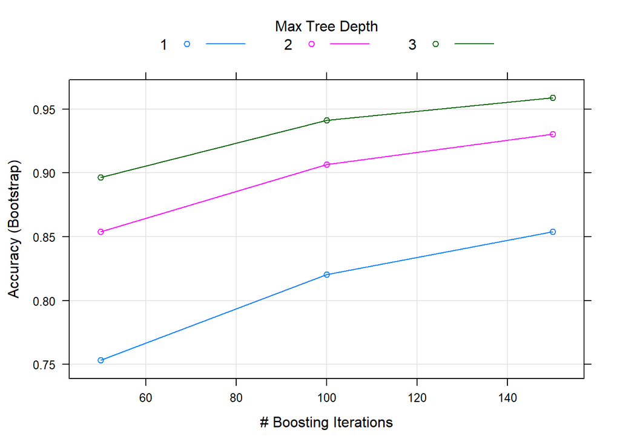

```r
plot(fit_boost)
```

Lets predict on cross-validation set and check its accuracy.

```r
pred_cv_boost <- predict(fit_boost, cv)
conf_cv_boost<-confusionMatrix(pred_cv_boost,cv$classe)
conf_cv_boost
```

```
## Confusion Matrix and Statistics
##
##           Reference
## Prediction    A    B    C    D    E
##          A 1381   28    0    1    2
##          B    9  897   31    0   17
##          C    4   23  817   34   10
##          D    1    1    7  765   17
##          E    0    0    0    4  855
##
## Overall Statistics
##
##                Accuracy : 0.9615
##                  95% CI : (0.9557, 0.9667)
##     No Information Rate : 0.2845
##     P-Value [Acc > NIR] : < 2.2e-16
##
##                   Kappa : 0.9512
##
##  Mcnemar's Test P-Value : 3.148e-11
##
## Statistics by Class:
##
##                      Class: A Class: B Class: C Class: D Class: E
## Sensitivity            0.9900   0.9452   0.9556   0.9515   0.9489
## Specificity            0.9912   0.9856   0.9825   0.9937   0.9990
## Pos Pred Value         0.9780   0.9403   0.9200   0.9671   0.9953
## Neg Pred Value         0.9960   0.9868   0.9905   0.9905   0.9886
## Prevalence             0.2845   0.1935   0.1743   0.1639   0.1837
## Detection Rate         0.2816   0.1829   0.1666   0.1560   0.1743
## Detection Prevalence   0.2879   0.1945   0.1811   0.1613   0.1752
## Balanced Accuracy      0.9906   0.9654   0.9690   0.9726   0.9740
```

Gradient boosting model has a great cross-validation accuracy of 96.1460033%.

## Fitting Random Forest Model

Now we will fit a random forest model and check its accuracy.

```r
fit_rf <- randomForest(classe ~ ., data=train)

conf_train_rf <- confusionMatrix(fit_rf$predicted,train$classe)
conf_train_rf
```

```
## Confusion Matrix and Statistics
##
##           Reference
## Prediction    A    B    C    D    E
##          A 4184   15    0    0    0
##          B    1 2826   14    0    0
##          C    0    7 2551   22    2
##          D    0    0    2 2388    4
##          E    0    0    0    2 2700
##
## Overall Statistics
##
##                Accuracy : 0.9953
##                  95% CI : (0.9941, 0.9964)
##     No Information Rate : 0.2843
##     P-Value [Acc > NIR] : < 2.2e-16
##
##                   Kappa : 0.9941
##
##  Mcnemar's Test P-Value : NA
##
## Statistics by Class:
##
##                      Class: A Class: B Class: C Class: D Class: E
## Sensitivity            0.9998   0.9923   0.9938   0.9900   0.9978
## Specificity            0.9986   0.9987   0.9974   0.9995   0.9998
## Pos Pred Value         0.9964   0.9947   0.9880   0.9975   0.9993
## Neg Pred Value         0.9999   0.9981   0.9987   0.9981   0.9995
## Prevalence             0.2843   0.1935   0.1744   0.1639   0.1839
## Detection Rate         0.2843   0.1920   0.1733   0.1623   0.1834
## Detection Prevalence   0.2853   0.1930   0.1754   0.1627   0.1836
## Balanced Accuracy      0.9992   0.9955   0.9956   0.9948   0.9988
```

Here we can see that our random forest model has a training accuracy of 99.5311863%.

Graph showing how error decrease by tree :

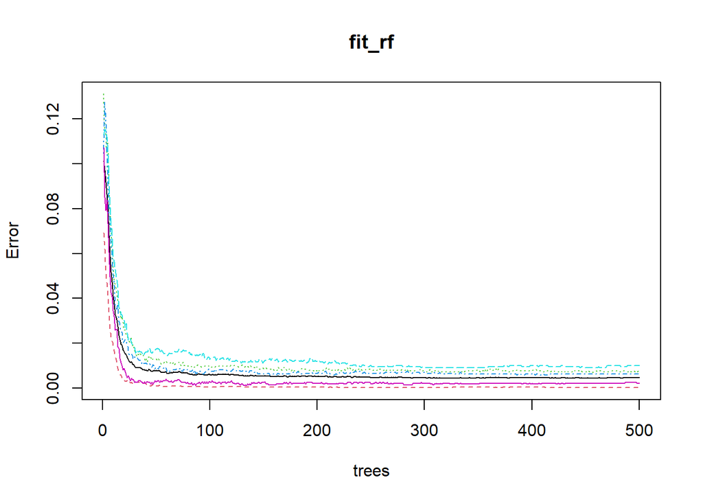

```r
plot(fit_rf)
```

Lets predict on cross-validation set and check its accuracy.

```r
pred_cv_rf <- predict(fit_rf, cv)
conf_cv_rf<-confusionMatrix(pred_cv_rf,cv$classe)
conf_cv_rf
```

```
## Confusion Matrix and Statistics
##
##           Reference
## Prediction    A    B    C    D    E
##          A 1394    1    0    0    0
##          B    0  946   11    0    0
##          C    0    2  844    9    1
##          D    0    0    0  795    4
##          E    1    0    0    0  896
##
## Overall Statistics
##
##                Accuracy : 0.9941
##                  95% CI : (0.9915, 0.996)
##     No Information Rate : 0.2845
##     P-Value [Acc > NIR] : < 2.2e-16
##
##                   Kappa : 0.9925
##
##  Mcnemar's Test P-Value : NA
##
## Statistics by Class:
##
##                      Class: A Class: B Class: C Class: D Class: E
## Sensitivity            0.9993   0.9968   0.9871   0.9888   0.9945
## Specificity            0.9997   0.9972   0.9970   0.9990   0.9998
## Pos Pred Value         0.9993   0.9885   0.9860   0.9950   0.9989
## Neg Pred Value         0.9997   0.9992   0.9973   0.9978   0.9988
## Prevalence             0.2845   0.1935   0.1743   0.1639   0.1837
## Detection Rate         0.2843   0.1929   0.1721   0.1621   0.1827
## Detection Prevalence   0.2845   0.1951   0.1746   0.1629   0.1829
## Balanced Accuracy      0.9995   0.9970   0.9921   0.9939   0.9971
```

Here also, random forest model has a near perfect accuracy of 99.408646%.

## Conclusion

We conclude that, Random Forest is predicting more accurate than Gradient Boosting Model with up-to 99% of accuracy level.

## Prediction (using Random Forest) on test data

```r
predict(fit_rf, test)
```

```
##  1  2  3  4  5  6  7  8  9 10 11 12 13 14 15 16 17 18 19 20
##  B  A  B  A  A  E  D  B  A  A  B  C  B  A  E  E  A  B  B  B
## Levels: A B C D E
```